# Project 2

Author

Hector Gavilanes

```r
library(tidyverse)
library(gsheet)
library(formattable)
library(DescTools) # perform Dunnett, Levene Test
library(pgirmess) # perform Kruskal-Wallis Post-hoc
library(ggpubr) # interaction plot
library(ggstatsplot) # boxplot graph
library(ISLR) # boxplot graph
library(knitr) #table format
```

**1. Consider a sample of data from the [Jackson Heart Study](https://www.jacksonheartstudy.org/). In this problem, we will be examining body mass index (*BMI*; kg/m<sup>2</sup>) as a function of health as categorized by physical activity (*PA3cat*; Ideal Health, Intermediate Health, and Poor Health).**

```r
# clear environment
rm(list = ls())
# import data
data <- as_tibble(gsheet2tbl("https://docs.google.com/spreadsheets/d/1H3TP-2SBMGleriJLESOe1cdCjtSj2F76bUh5iBqC8tI/edit#gid=2142000894"))
# clean data
clean_data <- data %>%
  select(BMI, BMI3cat) %>%
  drop_na()

# ---CUSTOM COLORS---
custom_green_dark = "#71CA97"
custom_green_light = "#DeF7E9"
custom_gray = "#3D3D3D"
custom_orange = "#FC7307"
custom_purple = "#5A18C9"
# custom_tan_light = "#F7E3D4"
custom_red_light = "#F7D0C7"
custom_red_dark = "#F1917C"
# custom_density_hue = c(custom_purple,custom_orange)
# ---FUNCTIONS---
# f00 - Change default table format
change_table_format <- function(data_table){
  # local variables
  first_column <- data_table[1]
  dataframe_length <- NCOL(data_table)
  # format
  formattable(data_table, align = c("l",rep("c", dataframe_length - 1)),
              list(first_column = formatter("span", style = ~ style(color = custom_gray, font.weight = "bold")),
              area(row = 1, col = 2:dataframe_length) ~ color_tile(custom_green_light, custom_green_dark),
              area(row = 3, col = 2:dataframe_length) ~ color_tile(custom_red_light, custom_red_dark)
              )#/end list
              )#/end formattable
}
# f01 - get custom summary statistics
# !! sym() creates a symbol from a string
get_custom_summary <- function(data_table, category, values){
  summary <- data_table %>%
    group_by(!! sym(category)) %>%
    summarise(Avg = mean(!! sym(values)),
              Median = median(!! sym(values)),
              SD = sd(!! sym(values)),
              Min = min(!! sym(values)),
              Max = max(!! sym(values)),
              IQRange = IQR(!! sym(values)),
              Count = length(!!sym(values))
              )
    return(summary)
}
```

**a. Find the appropriate summary statistics to summarize the data.**

```r
change_table_format(get_custom_summary(clean_data, "BMI3cat", "BMI"))
```

| BMI3cat | Avg | Median | SD | Min | Max | IQRange | Count |
| --- | --- | --- | --- | --- | --- | --- | --- |
| Ideal Health | 22.78914 | 23.34 | 1.798843 | 18.53 | 25.00 | 2.42 | 347 |
| Intermediate Health | 27.60544 | 27.62 | 1.413412 | 25.00 | 29.99 | 2.53 | 869 |
| Poor Health | 36.63521 | 35.06 | 5.845224 | 30.00 | 59.57 | 6.68 | 1433 |

- The ideal BMI group has a mean of 22.79, followed by the intermediate group with 27.61 and 36.64 for the poor health group. The poor health group represents the majority with 54.09% of total observations 2,649.
- The standard deviation for ideal and intermediate groups are similar at 1.79 and 1.41, respectively. Interestingly enough, the poor health group has a value of 5.85. The higher standard deviation indicates the data points are more dispersed.
- The ideal group has a higher median value than its mean, indicating a skewed data distribution.

**b. Use ANOVA to determine if there is a difference in BMI between the three levels of health as categorized by physical activity. Test at the $\alpha=0.05$ level.**

```r
# One-way ANOVA
# Null Hypothesis:
# - H0: All means of observations grouped by BMI category are the same
# - H1: At least one category is different

h1 <- aov(clean_data$BMI ~ clean_data$BMI3cat)
summary(h1)
```

```
                     Df Sum Sq Mean Sq F value Pr(>F)
clean_data$BMI3cat    2  76958   38479    1966 <2e-16 ***
Residuals          2646  51780      20
---
Signif. codes:  0 '***' 0.001 '**' 0.01 '*' 0.05 '.' 0.1 ' ' 1
```

### Hypothesis

- $H_0$: $\mu Ideal = \mu Intermediate\ = \mu Poor$
- $H_1$: at least one is different

### Test Statistic

- $F_0 = 1966$

### p-Value

- $p < 0.001$

## Conclusion

Reject $H_0$ at the $\alpha$=0.05 level. There is sufficient evidence to suggest that there is a difference in BMI between the three levels of health.

**c. Use the Kruskal-Wallis to determine if there is a difference in BMI between the three levels of health as categorized by physical activity (*PA3cat*; Ideal Health, Intermediate Health, and Poor Health). Test at the $\alpha=0.05$ level.**

```r
kruskal.test(clean_data$BMI ~ clean_data$BMI3cat)
```

```
    Kruskal-Wallis rank sum test

data:  clean_data$BMI by clean_data$BMI3cat
Kruskal-Wallis chi-squared = 2129.4, df = 2, p-value < 2.2e-16
```

### Hypothesis: Kruskal-Wallis

- $H_0$: $M_{Ideal} = M_{Intermediate} = M_{Poor}$
- $H_1$: at least one group is different

### Test Statistic

- $H = 2129.4$

### p-Value

- $p < 0.001$

## Conclusion

Reject $H_0$ at the $\alpha$=0.05 level. There is sufficient evidence to suggest that there is a difference in BMI between the three levels of health.

**d. State/explain the ANOVA assumptions and assess them. Remember to state your conclusion (that you either meet the ANOVA assumptions or you do not).**

We are unwilling to assume normality because we have found the assumption of normality invalid in diagnostic checks. We have performed the following ANOVA assumptions:

1. Independence – the observations in each group need to be independent of each other. The data provided meets this requirement.
2. Normality – the dependent variable should be approximately normally distributed for each combination of the groups. However, the residuals are not normally distributed; thus, we cannot assume normality.

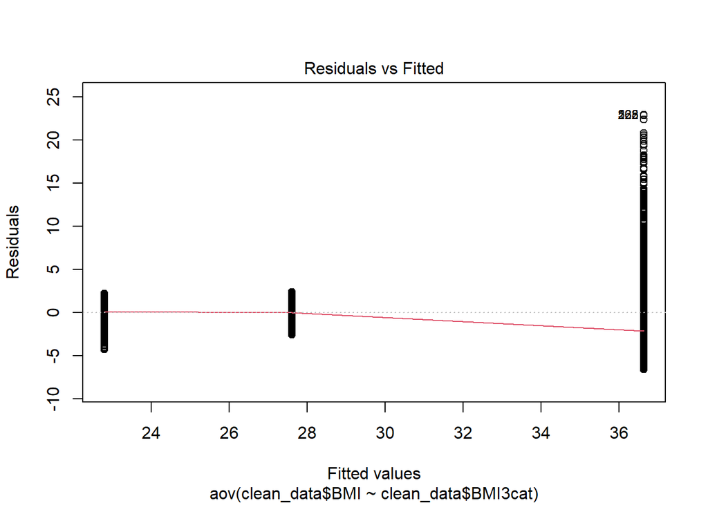

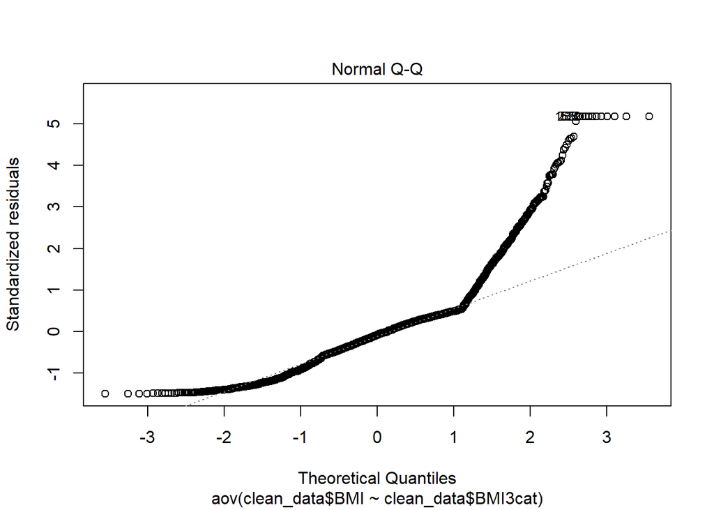

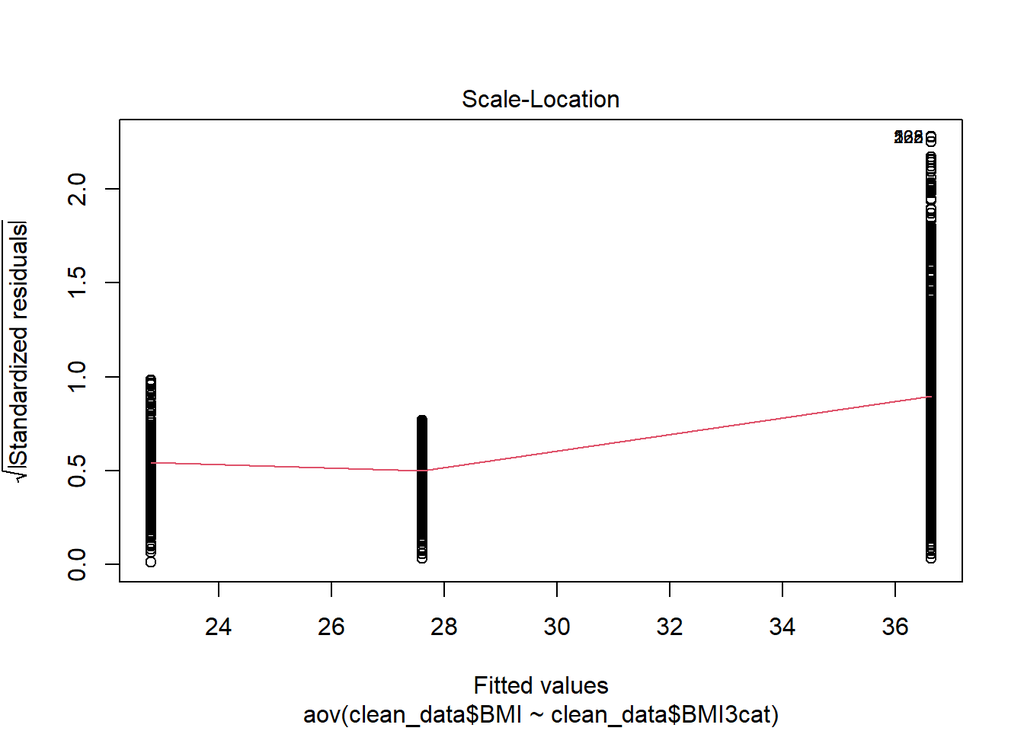

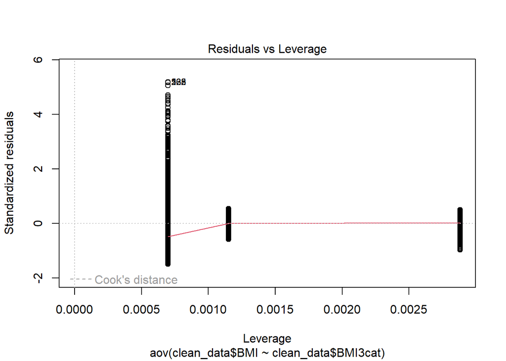

```r
# 2. Normality check
plot(h1)
```

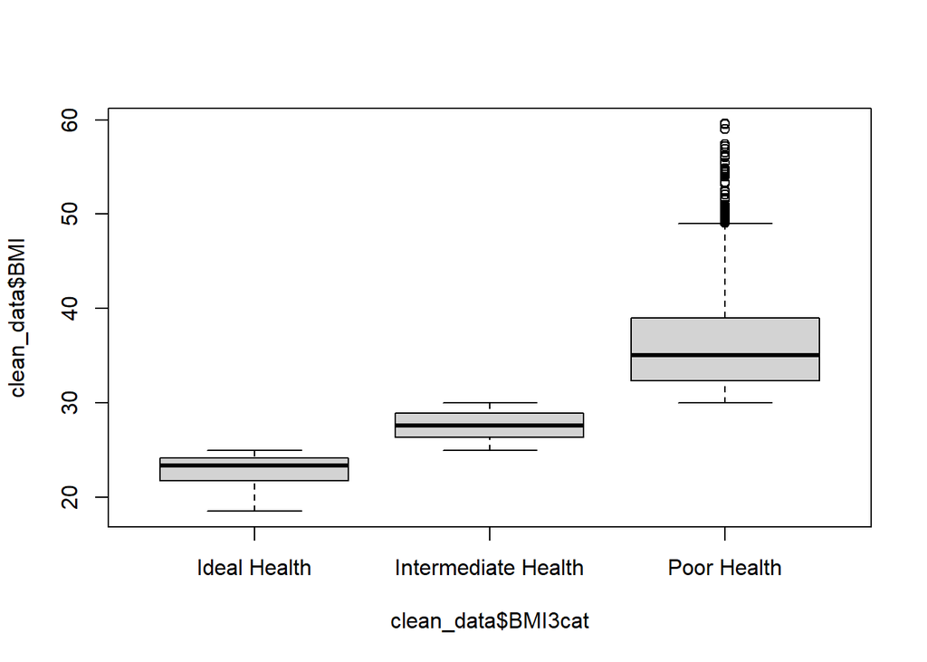

```r
boxplot(clean_data$BMI ~ clean_data$BMI3cat)
```

3. Equal Variance - the variances for each group are equal or approximately equal. Since the p-value < 0.001 which is lower than our 0.05 level of significance, we cannot assume equality of variances.

```r
# 3. Levene's test for equality of variance
LeveneTest(clean_data$BMI ~ clean_data$BMI3cat,
           exact = FALSE)
```

```
Levene's Test for Homogeneity of Variance (center = median: FALSE)
        Df F value    Pr(>F)
group    2  283.73 < 2.2e-16 ***
      2646
---
Signif. codes:  0 '***' 0.001 '**' 0.01 '*' 0.05 '.' 0.1 ' ' 1
```

**e. Based on your responses in part (d), which test’s result are you going to present to the lead scientist at the JHS? (Hint: you will pick either (b) or (c)).**

Nonparametric test, Kruskal-Wallis, in this case.

**f. Perform the appropriate post-hoc test to determine pairwise differences between the three groups. Test at the $\alpha=0.05$ level.**

### Non-Parametric Post-hoc Pairwise Comparison

```r
# Kruskal-Wallis post-hoc
kruskalmc(clean_data$BMI ~ clean_data$BMI3cat)
```

```
Multiple comparison test after Kruskal-Wallis
p.value: 0.05
Comparisons
                                  obs.dif critical.dif difference
Ideal Health-Intermediate Health  607.998    116.27489       TRUE
Ideal Health-Poor Health         1758.999    109.55090       TRUE
Intermediate Health-Poor Health  1151.001     78.72514       TRUE
```

```r
# nonparametric post-hoc DunnTest with p-values
DunnTest(clean_data$BMI ~ clean_data$BMI3cat,
         method = "bonferroni")
```

```
 Dunn's test of multiple comparisons using rank sums : bonferroni

                                 mean.rank.diff   pval
Intermediate Health-Ideal Health        607.998 <2e-16 ***
Poor Health-Ideal Health               1758.999 <2e-16 ***
Poor Health-Intermediate Health        1151.001 <2e-16 ***
---
Signif. codes:  0 '***' 0.001 '**' 0.01 '*' 0.05 '.' 0.1 ' ' 1
```

- Dunn’s test pairwise comparison determined that all groups had significant variance among each other.
- All groups had a p-value < 0.001, lower than 0.05 level of significance.
- Due to multiple comparisons at once, we controlled the family-wise error rate with the Bonferroni adjustment method.

**g. Write a brief paragraph describing the results of your analysis. Include summary statistics, results of your chosen hypothesis test from part (e), results of the post-hoc test in part (f), and a graph to help convey the results.**

## Analisis

The ANOVA assumptions were invalid after normality checks and Levene’s test. Therefore, to find a statistically significant difference in BMI between the three levels of health (poor, intermediate, and ideal), a nonparametric Kruskal-Wallis test was conducted. The procedure following a Kruskal-Wallis test was to perform a Dunn’s post-hoc pairwise comparison.

## Conclusion

The poor health group represented the majority of the sample with 54.09% of total observations 2,649.

It is recommended to increase physical activity to have a better BMI calculation.

### Summary Statistics

To better understood the data, we calculated the mean, median, and standard deviation.

| BMI3cat | Avg | Median | SD | Min | Max | IQRange | Count |
| --- | --- | --- | --- | --- | --- | --- | --- |
| Ideal Health | 22.78914 | 23.34 | 1.798843 | 18.53 | 25.00 | 2.42 | 347 |
| Intermediate Health | 27.60544 | 27.62 | 1.413412 | 25.00 | 29.99 | 2.53 | 869 |
| Poor Health | 36.63521 | 35.06 | 5.845224 | 30.00 | 59.57 | 6.68 | 1433 |

- The ideal BMI group had a mean of 22.79, followed by the intermediate and poor health group with 27.61 and 36.64, respectively. The poor health group had the majority of the observations with 54.09% of the total of 2,649.
- The standard deviation for ideal and intermediate groups were similar at 1.79 and 1.41, respectively. Interestingly enough, the poor health group had a value of 5.85. The higher standard deviation indicates the data points were more dispersed.
- The ideal group had a higher median value than its mean, indicated a skewed data distribution.

### ANOVA Assumptions

We were unwilling to assume normality because we have found the assumption of normality invalid in diagnostic checks. We have performed the following ANOVA assumptions:

- **1. Independence** – the observations in each group need to be independent of each other. The data provided met this requirement.
- **2. Normality** – the dependent variable should be approximately normally distributed for each combination of the groups. However, the residuals were not normally distributed; thus, normality was not assumed.

The *Fitted vs. Residuals* graph showed how the residuals had differences in size among the groups.

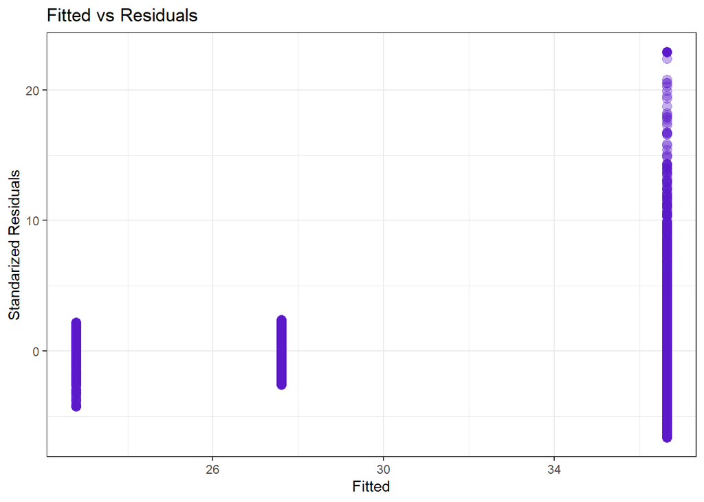

The *QQ (quantile-quantile) plot* did not display the normality of residuals. The residuals did not follow the 45-degree line.

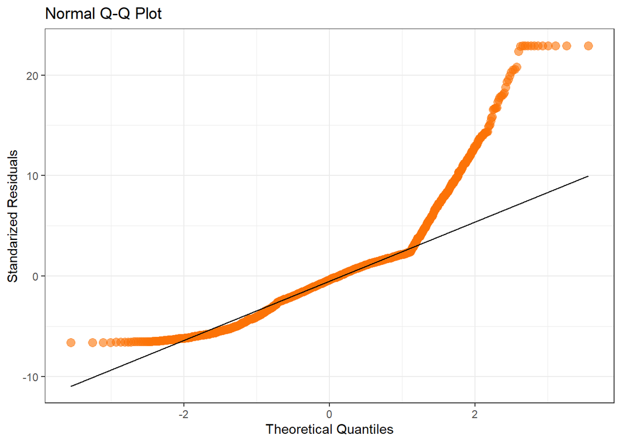

Moreover, a *Boxplot* displayed the distribution of BMI health for each group with significant differences, and outliers.

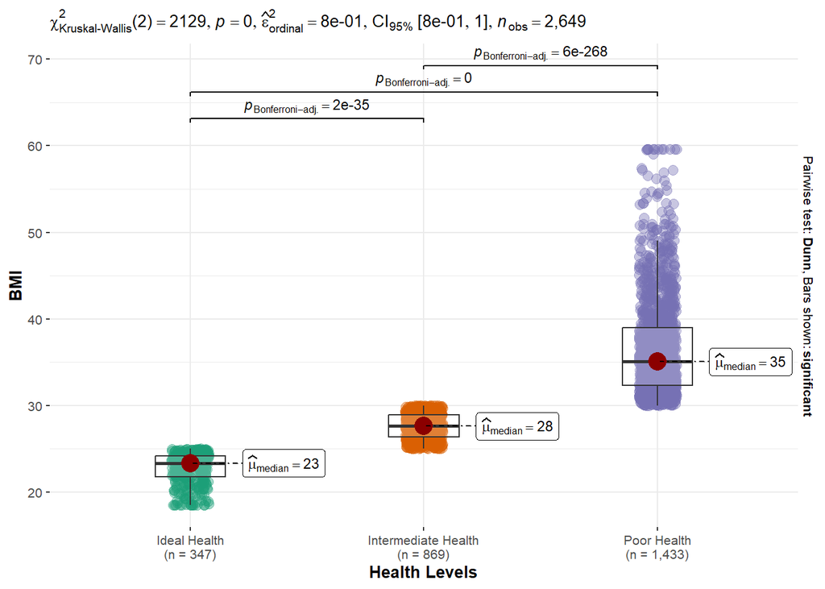

**3. Equal Variance** - the variances for each group are equal or approximately equal.

Since the p-value < 0.001 was lower than 0.05 level of significance, we did not assume equality of variances.

```
Levene's Test for Homogeneity of Variance (center = median: FALSE)
        Df F value    Pr(>F)
group    2  283.73 < 2.2e-16 ***
      2646
---
Signif. codes:  0 '***' 0.001 '**' 0.01 '*' 0.05 '.' 0.1 ' ' 1
```

The ANOVA assumptions are invalid.

### Kruskal-Wallis Test

We used a nonparametric alternative to ANOVA test.

```
    Kruskal-Wallis rank sum test

data:  clean_data$BMI by clean_data$BMI3cat
Kruskal-Wallis chi-squared = 2129.4, df = 2, p-value < 2.2e-16
```

#### Hypothesis:

- $H_0$: $M_{Ideal} = M_{Intermediate} = M_{Poor}$
- $H_1$: at least one group is different

#### Test Statistic

- $H = 2129.4$

#### p-Value

- $p < 0.001$

#### Conclusion

Rejected $H_0$ at the $\alpha$=0.05 level. There was sufficient evidence to suggest that there was a difference in BMI between the three levels of health.

### Post-hoc Dunn’s Test

- Dunn’s test pairwise comparison determined that all groups had significant variance among each other.
- All groups had a p-value < 0.001 lower than 0.05 level of significance.
- Due to multiple comparisons at once, we controlled the family-wise error rate with the Bonferroni adjustment method.

[output not shown]

## Part 2

**2. Again, consider the sample of data from the JHS. In this problem, we will be examining systolic blood pressure (*sbp*; mmHg) as a function of health as categorized by body mass index (*BMI3cat*; Ideal Health, Intermediate Health, and Poor Health), smoking status (*everSmoker*; 0=never smoker, 1=former or current smoker), and the interaction between health as categorized by body mass index and smoking status.**

```r
blood_data <- data %>%
  select(BMI3cat, sbp, everSmoker) %>%
  drop_na()
```

**a. Find the appropriate summary statistics to summarize the data.**

The summary by BMI and Smoker group was calculated in the following order: Mean, Standard Deviation, Median, Min, Max.

```r
# functions for FUN attribute
multiple_func <- function(x) {
  c(mean = mean(x), sd = sd(x), median = median(x), min = min(x), max = max(x))
}

# summary by BMI and Smoker group
pressure_summary <-tapply(blood_data$sbp,
                       INDEX = list(blood_data$BMI3cat, blood_data$everSmoker),
                       FUN = multiple_func)
pressure_summary <- as.data.frame(pressure_summary)
# print table
kable(pressure_summary, col.names = c("Non-Smoker", "Smoker"))
```

|  | Non-Smoker | Smoker |
| --- | --- | --- |
| Ideal Health | 121.44656, 15.00189, 119.25000, 93.57000, 187.10000 | 127.02537, 18.51499, 124.75000, 96.32000, 188.93000 |
| Intermediate Health | 124.96071, 14.81666, 122.91000, 93.57000, 188.93000 | 126.83404, 16.60876, 123.83000, 93.57000, 184.35000 |
| Poor Health | 126.98123, 15.45626, 125.66000, 93.57000, 188.93000 | 127.12447, 14.86128, 125.20500, 93.57000, 188.93000 |

**b. Use ANOVA to determine if there is a difference in systolic blood pressure between health as categorized by body mass index, smoking status, and the interaction between health as categorized by body mass index and smoking status. Test at the $\alpha=0.05$ level. Remember to remove the interaction term if appropriate to do so.**

```r
# Two-way ANOVA with Interaction
# Null Hypothesis:
# - H1: The means of observations grouped by Health Levels are the same
# - H2: The means of observations grouped by Smoking are the same
# - H3: There is no interaction between Health Levels and Smoking

blood_interaction = blood_data$sbp ~ factor(blood_data$BMI3cat) * factor(blood_data$everSmoker)
lm_model_blood = lm(blood_interaction)

# ANOVA Model
anova_model <- summary(two_way <- aov(sbp ~ BMI3cat * everSmoker, data = blood_data))
anova_model
```

```
                     Df Sum Sq Mean Sq F value  Pr(>F)
BMI3cat               2   3619  1809.7   7.546 0.00054 ***
everSmoker            1   1300  1300.1   5.421 0.01997 *
BMI3cat:everSmoker    2   1920   960.1   4.003 0.01837 *
Residuals          2635 631912   239.8
---
Signif. codes:  0 '***' 0.001 '**' 0.01 '*' 0.05 '.' 0.1 ' ' 1
```

### Hypothesis

- $H_0$: There is no interaction between Health levels and Smoking status
- $H_1$: There is an interaction between Health levels and Smoking status

### Test Statistic

- $F_{Health-Smoking} = 4.003$

### p-Value

- $p = 0.01837$

### Conclusion

Reject $H_0$ at the $\alpha$=0.05 level. There is sufficient evidence to suggest that there is an interaction between Health levels (ideal, intermediate, and poor), and Smoking status.

In other words, the relationship between blood pressure and Health Levels depends on the Smoking status. No further hypothesis are required because there is an interaction between Health levels and Smoking status.

**c. Construct a profile plot to help explain results of part (b).**

Using Rstudio function to have a general idea of the plot.

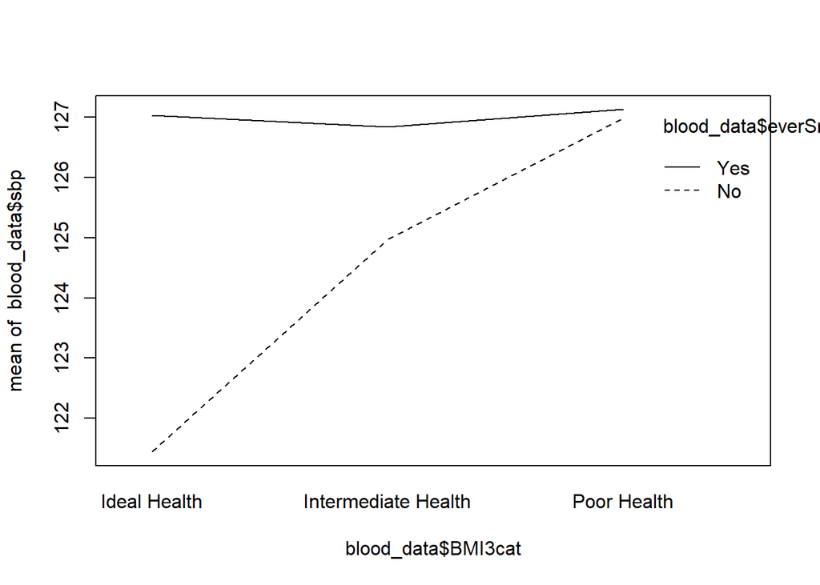

```r
interaction.plot(blood_data$BMI3cat, blood_data$everSmoker, blood_data$sbp, mean)
```

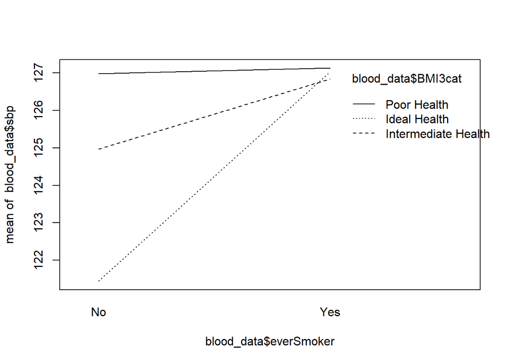

```r
interaction.plot(blood_data$everSmoker, blood_data$BMI3cat, blood_data$sbp, mean)
```

Interaction plot using ggplot.

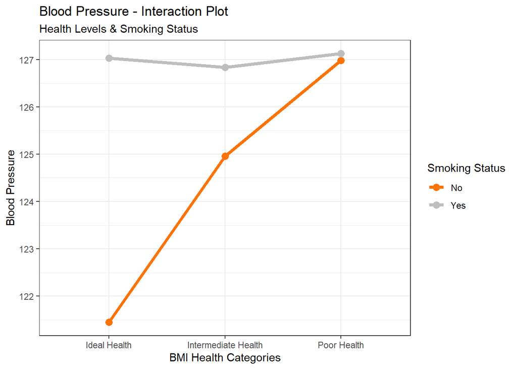

```r
gg_mean <- blood_data %>%
  group_by(BMI3cat, everSmoker) %>%
  summarise(mean_groups = mean(sbp),
            .groups = "keep")

p <- gg_mean %>%
  ggplot(aes(x = BMI3cat, y = mean_groups, color = everSmoker))+
  geom_line(aes(group = gg_mean$everSmoker), size = 1.5)+
  geom_point(size = 3)+
  labs(title = "Blood Pressure - Interaction Plot", subtitle = "Health Levels & Smoking Status", color = "Smoking Status")+
  xlab("BMI Health Categories")+
  ylab("Blood Pressure")+
  scale_color_manual(values = c(custom_orange, "gray"))+
  theme_bw()
p
```

Another way to represent the interaction.

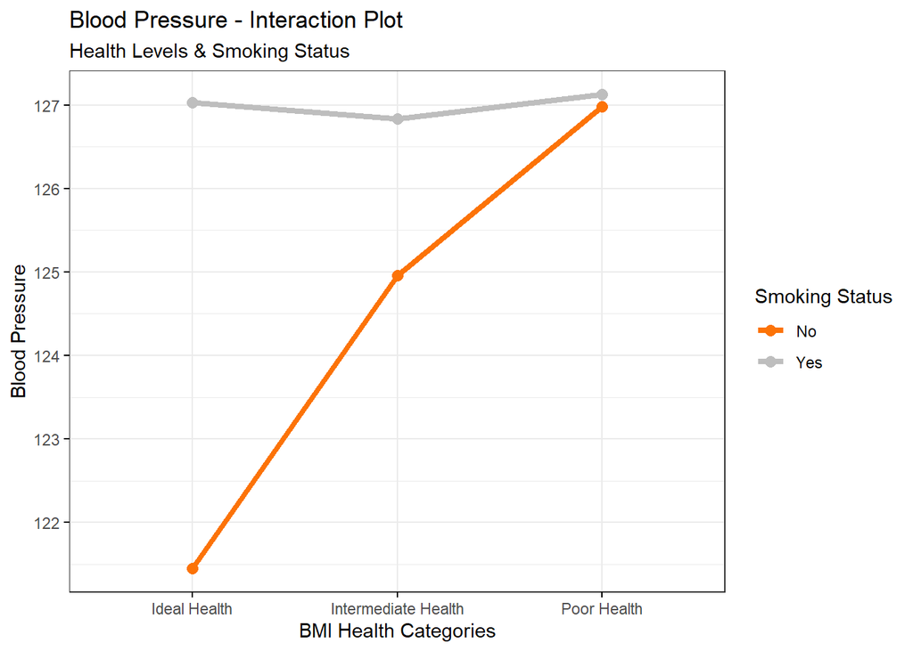

```r
# profile plot using ggline
# health levels
bmi_categories <- factor(blood_data$BMI3cat, levels = c("Ideal Health", "Intermediate Health", "Poor Health"))
profile <- ggline(blood_data, x = "BMI3cat", y = "sbp", color = "everSmoker",
       add = "mean",
       size = 1.5,
       order = c("Ideal Health", "Intermediate Health", "Poor Health"),
       palette = c(custom_orange, "gray"),
       ylab = "Blood Pressure",
       xlab = "BMI Health Categories",)+
  theme_bw()

interaction_health <- ggpar(profile,
                      main = "Blood Pressure - Interaction Plot",
                      submain = "Health Levels & Smoking Status",
                      legend.title = "Smoking Status",
                      legend = "right")

interaction_health
```

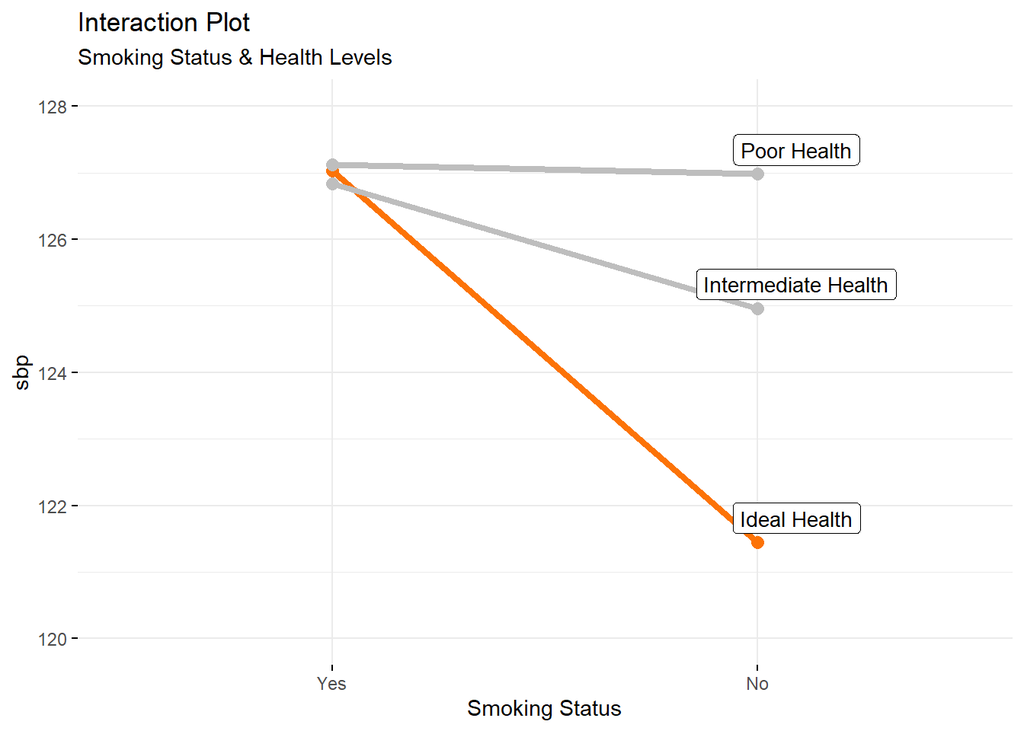

```r
# smoking status
profile_smoke <- ggline(blood_data, x = "everSmoker", y = "sbp", color = "BMI3cat",
       add = "mean",
       show.line.label = TRUE,
       label.rectangle = TRUE,
       repel = TRUE,
       size = 1.5,
       palette = c(custom_orange, "gray", "gray"),
       xlab = "Smoking Status",)+
  theme_minimal()
interaction_smoke <- ggpar(profile_smoke,
                      main = "Interaction Plot",
                      submain = "Smoking Status & Health Levels",
                      legend = "none",
                      ylim = c(120, 128))
interaction_smoke
```

**d. Use the appropriate post-hoc test to determine differences in main effects or the interaction term, whichever is appropriate for the results in part (b). Test at the $\alpha=0.05$ level.**

## ANOVA Assumption

### 1. Independence

The sample data are independent from each other.

### 2. Normality

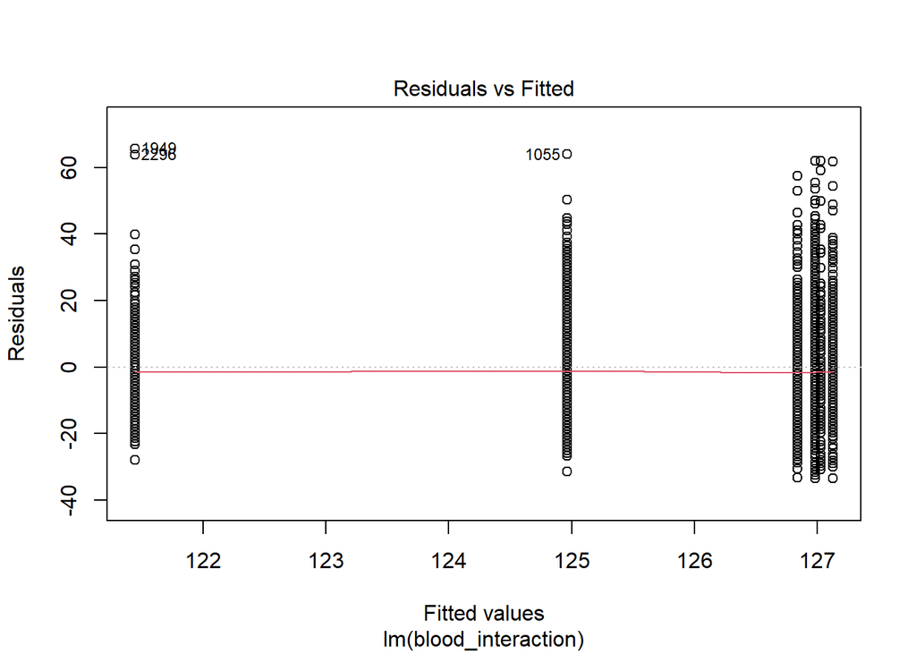

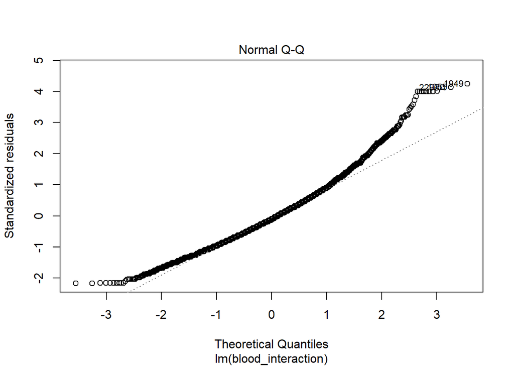

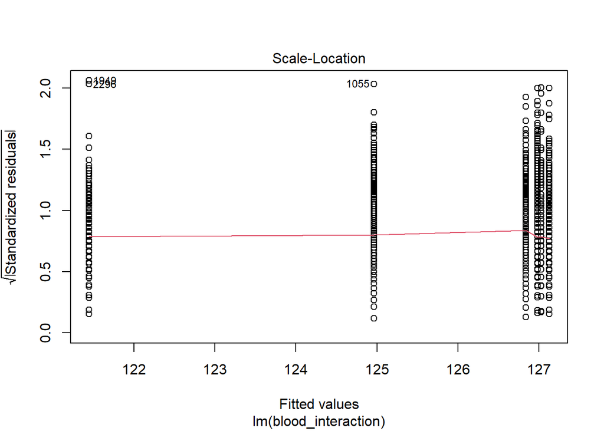

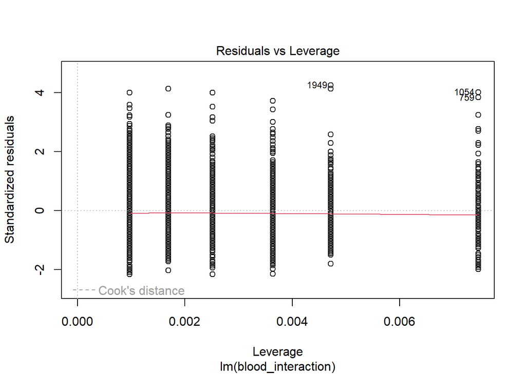

```r
plot(lm_model_blood)
```

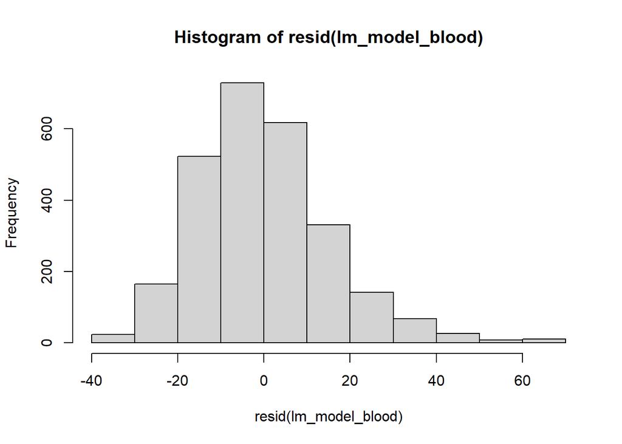

```r
# histogram
hist(resid(lm_model_blood))
```

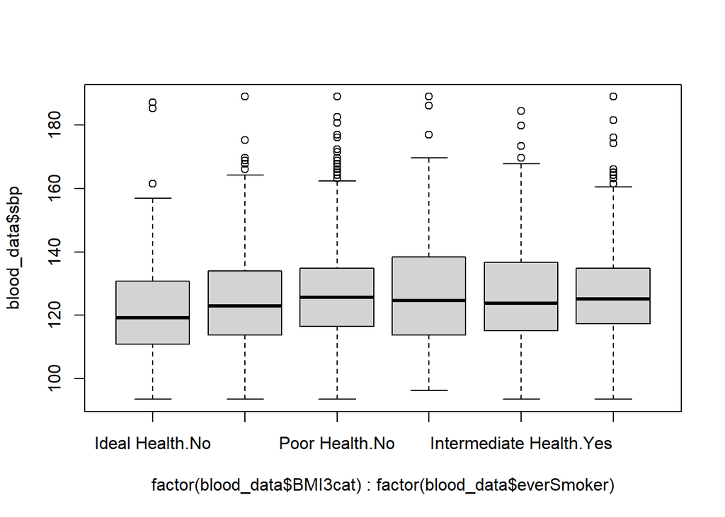

```r
# boxplot
boxplot(blood_interaction)
```

Visually, the data has some outliers towards the right tail; nonetheless, the data does not represent a concern to invalidate the normality assumption.

### 3. Equal Variance: Levene’s Test for Equality of Variances

```r
LeveneTest(blood_data$sbp ~ factor(blood_data$BMI3cat))
```

```
Levene's Test for Homogeneity of Variance (center = median)
        Df F value Pr(>F)
group    2  1.8099 0.1639
      2638
```

```r
LeveneTest(blood_data$sbp ~ factor(blood_data$everSmoker))
```

```
Levene's Test for Homogeneity of Variance (center = median)
        Df F value Pr(>F)
group    1  1.1822  0.277
      2639
```

The ANOVA assumptions are valid.

### Interaction Post-hoc

```r
TukeyHSD(aov(blood_interaction))
```

```
  Tukey multiple comparisons of means
    95% family-wise confidence level

Fit: aov(formula = blood_interaction)

$`factor(blood_data$BMI3cat)`
                                     diff        lwr      upr     p adj
Intermediate Health-Ideal Health 1.947763 -0.3614752 4.257002 0.1178561
Poor Health-Ideal Health         3.414017  1.2380080 5.590025 0.0006980
Poor Health-Intermediate Health  1.466254 -0.0972673 3.029774 0.0714917

$`factor(blood_data$everSmoker)`
           diff       lwr      upr     p adj
Yes-No 1.518403 0.2356789 2.801127 0.0203552

$`factor(blood_data$BMI3cat):factor(blood_data$everSmoker)`
                                                      diff         lwr
Intermediate Health:No-Ideal Health:No          3.51415286 -0.02058643
Poor Health:No-Ideal Health:No                  5.53467641  2.20400030
Ideal Health:Yes-Ideal Health:No                5.57881653  0.70492493
Intermediate Health:Yes-Ideal Health:No         5.38747976  1.35113411
Poor Health:Yes-Ideal Health:No                 5.67791576  1.92288415
Poor Health:No-Intermediate Health:No           2.02052355 -0.25721622
Ideal Health:Yes-Intermediate Health:No         2.06466367 -2.16020490
Intermediate Health:Yes-Intermediate Health:No  1.87332690 -1.34952608
Poor Health:Yes-Intermediate Health:No          2.16376290 -0.69892073
Ideal Health:Yes-Poor Health:No                 0.04414012 -4.01153935
Intermediate Health:Yes-Poor Health:No         -0.14719665 -3.14482952
Poor Health:Yes-Poor Health:No                  0.14323935 -2.46328689
Intermediate Health:Yes-Ideal Health:Yes       -0.19133677 -4.84399396
Poor Health:Yes-Ideal Health:Yes                0.09909923 -4.31172780
Poor Health:Yes-Intermediate Health:Yes         0.29043600 -3.17260629
                                                     upr     p adj
Intermediate Health:No-Ideal Health:No          7.048892 0.0523817
Poor Health:No-Ideal Health:No                  8.865353 0.0000333
Ideal Health:Yes-Ideal Health:No               10.452708 0.0141462
Intermediate Health:Yes-Ideal Health:No         9.423825 0.0019989
Poor Health:Yes-Ideal Health:No                 9.432947 0.0002423
Poor Health:No-Intermediate Health:No           4.298263 0.1158485
Ideal Health:Yes-Intermediate Health:No         6.289532 0.7309495
Intermediate Health:Yes-Intermediate Health:No  5.096180 0.5601333
Poor Health:Yes-Intermediate Health:No          5.026447 0.2592685
Ideal Health:Yes-Poor Health:No                 4.099820 1.0000000
Intermediate Health:Yes-Poor Health:No          2.850436 0.9999925
Poor Health:Yes-Poor Health:No                  2.749766 0.9999869
Intermediate Health:Yes-Ideal Health:Yes        4.461320 0.9999969
Poor Health:Yes-Ideal Health:Yes                4.509926 0.9999998
Poor Health:Yes-Intermediate Health:Yes         3.753478 0.9998937
```

- The ideal non-smoker group was significantly different from the smoker group.
- The ideal non-smoker group was significantly different from non-smokers in the poor health group.
- The ideal non-smoker group was significantly different from smokers in either poor, and intermediate group.
- The ideal group was significantly different from the poor health group.

**e. Write a brief paragraph describing the results of your analysis. Include summary statistics, results of the hypothesis testing in part (b), results of the post-hoc test in part (d), and the profile plot in part (c) to help convey the results.**

## Conclusion

There was a significant exponential difference between poor and ideal health levels depended among smokers and non-smokers. People who smoke scored higher in blood pressure results regardless of their health level. On the other hand, non-smokers from intermediate and ideal health groups had better blood pressure than the poor health group. Interestingly enough, there was an antagonist interaction between ideal and intermediate health groups depended on the smoking status.

The ideal health level group showcased that non-smokers with great physical activity had the best blood pressure.

It is recommended to limit the consumption of cigarettes and increase physical activity to improve blood pressure.

### Summary Statistics

The summary by BMI and Smoker group was calculated in the following order: Mean, Standard Deviation, Median, Min, Max.

|  | Non-Smoker | Smoker |
| --- | --- | --- |
| Ideal Health | 121.44656, 15.00189, 119.25000, 93.57000, 187.10000 | 127.02537, 18.51499, 124.75000, 96.32000, 188.93000 |
| Intermediate Health | 124.96071, 14.81666, 122.91000, 93.57000, 188.93000 | 126.83404, 16.60876, 123.83000, 93.57000, 184.35000 |
| Poor Health | 126.98123, 15.45626, 125.66000, 93.57000, 188.93000 | 127.12447, 14.86128, 125.20500, 93.57000, 188.93000 |

### Two-way ANOVA Model

```
                     Df Sum Sq Mean Sq F value  Pr(>F)
BMI3cat               2   3619  1809.7   7.546 0.00054 ***
everSmoker            1   1300  1300.1   5.421 0.01997 *
BMI3cat:everSmoker    2   1920   960.1   4.003 0.01837 *
Residuals          2635 631912   239.8
---
Signif. codes:  0 '***' 0.001 '**' 0.01 '*' 0.05 '.' 0.1 ' ' 1
```

### Hypothesis

- $H_0$: There is no interaction between Health levels and Smoking status
- $H_1$: There is an interaction between Health levels and Smoking status

### Test Statistic

- $F_{Health-Smoking} = 4.003$

### p-Value

- $p = 0.01837$

### Conclusion

Rejected $H_0$ at the $\alpha$=0.05 level. There was sufficient evidence to suggest that there was an interaction between Health levels (ideal, intermediate, and poor), and Smoking status.

In other words, the relationship between blood pressure and Health Levels depended on the Smoking status.

### Interaction Plot

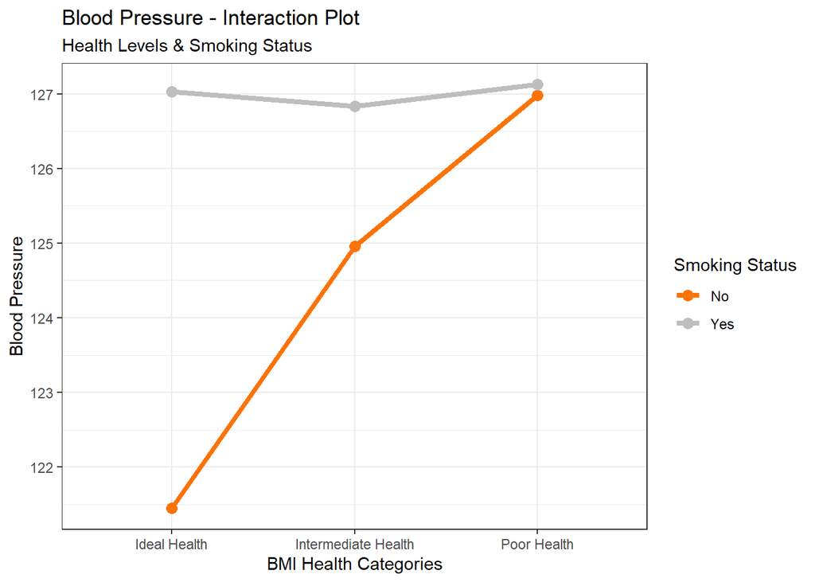

## Parametric Post-hoc

### Health Levels & Smoking Status Interactions

For the following significant results, only p-values < 0.05 were selected.

| Interactions | diff | lwr | upr | p adj |
| --- | --- | --- | --- | --- |
| Poor Health:No-Ideal Health:No | 5.534676 | 2.2040003 | 8.865353 | 0.0000333 |
| Ideal Health:Yes-Ideal Health:No | 5.578817 | 0.7049249 | 10.452708 | 0.0141462 |
| Intermediate Health:Yes-Ideal Health:No | 5.387480 | 1.3511341 | 9.423825 | 0.0019989 |
| Poor Health:Yes-Ideal Health:No | 5.677916 | 1.9228841 | 9.432947 | 0.0002423 |

- The ideal non-smoker group was significantly different from the smoker group.
- The ideal non-smoker group was significantly different from non-smokers in the poor health group.
- The ideal non-smoker group was significantly different from smokers in either poor, and intermediate group.

### Health Levels

| Health Levels | diff | lwr | upr | p adj |
| --- | --- | --- | --- | --- |
| Poor Health-Ideal Health | 3.414017 | 1.238008 | 5.590025 | 0.000698 |

### Smoking Status

| Smoking Status | diff | lwr | upr | p adj |
| --- | --- | --- | --- | --- |
| Yes-No | 1.518403 | 0.2356789 | 2.801127 | 0.0203552 |

- The ideal group was significantly different from the poor health group.